# ashishsa_hw1_p3

We have to Cluster the Demographic Data using a Classification Tree. First we load the data and we first check the data using head.

```r
rm(list=ls(all=T))
library(loadr)
load("C:/Users/ashis/OneDrive/Desktop/New folder (2)/HW1/ElemStatLearn/data/marketing.RData")
head(marketing)
```

```
##   Income Sex Marital Age Edu Occupation Lived Dual_Income Household
## 1      9   2       1   5   4          5     5           3         3
## 2      9   1       1   5   5          5     5           3         5
## 3      9   2       1   3   5          1     5           2         3
## 4      1   2       5   1   2          6     5           1         4
## 5      1   2       5   1   2          6     3           1         4
## 6      8   1       1   6   4          8     5           3         2
##   Householdu18 Status Home_Type Ethnic Language
## 1            0      1         1      7       NA
## 2            2      1         1      7        1
## 3            1      2         3      7        1
## 4            2      3         1      7        1
## 5            2      3         1      7        1
## 6            0      1         1      7        1
```

```r
View(marketing)
```

We need to create a Reference Dataset which has the same size as the Training set. We first check the number of rows in the dataset.

```r
nrow(marketing)
```

```
## [1] 8993
```

```r
ncol(marketing)
```

```
## [1] 14
```

We first need to check if there are NAN values present in the dataset. We find if NaN values are present in theparticular column then we replace those NaN values with column means.

```r
library(tidyr)
col_means <- lapply(marketing, mean, na.rm = TRUE)
data1 <- replace_na(marketing, col_means)
```

Now we make the Reference Dataset by finding the range of each column in the dataset.We find the minimum and maximum values of each column in the dataset.

```r
Income_max <- max(data1$Income)
Income_min <- min(data1$Income)
Sex_max <- max(data1$Sex)
Sex_min <- min(data1$Sex)
Marital_max <- max(data1$Marital)
Marital_min <- min(data1$Marital)
Age_max <- max(data1$Age)
Age_min <- min(data1$Age)
Edu_max <- max(data1$Edu)
Edu_min <- min(data1$Edu)
Occupation_max <- max(data1$Occupation)
Occupation_min <- min(data1$Occupation)
Lived_max <- max(data1$Lived)
Lived_min <- min(data1$Lived)
Dual_Income_max <- max(data1$Dual_Income)
Dual_Income_min <- min(data1$Dual_Income)
Household_max <- max(data1$Household)
Household_min <- min(data1$Household)
Householdu_max <- max(data1$Householdu18)
Householdu_min <- min(data1$Householdu18)
Status_max <- max(data1$Status)
Status_min <- min(data1$Status)
Hometype_max <- max(data1$Home_Type)
Hometype_min <- min(data1$Home_Type)
Ethnic_max <- max(data1$Ethnic)
Ethnic_min <- min(data1$Ethnic)
Language_max <- max(data1$Language)
Language_min <- min(data1$Language)
```

We now create new variables using the max and min function.

```r
Income <- sample(rep(Income_min:Income_max,len=8993))
Sex <- sample(rep(Sex_min:Sex_max,len=8993))
Marital <- sample(rep(Marital_min:Marital_max,len=8993))
Age <- sample(rep(Age_min:Age_max,len=8993))
Edu <- sample(rep(Edu_min:Edu_max,len=8993))
Occupation <- sample(rep(Occupation_min:Occupation_max,len=8993))
Lived <- sample(rep(Lived_min:Lived_max,len=8993))
Dual_Income <- sample(rep(Dual_Income_min:Dual_Income_max,len=8993))
Household <- sample(rep(Household_min:Household_max,len=8993))
Householdu18 <- sample(rep(Householdu_min:Householdu_max,len=8993))
Status <- sample(rep(Status_min:Status_max,len=8993))
Home_Type <- sample(rep(Hometype_min:Hometype_max,len=8993))
Ethnic <- sample(rep(Ethnic_min:Ethnic_max,len=8993))
Language <- sample(rep(Language_min:Language_max,len=8993))
```

We now make a data frame for the Reference Sample from the variables created above.

```r
reference_sample <- data.frame(Income,Sex,Marital,Age,Edu,Occupation,Lived,Dual_Income,Household,Householdu18,Status,Home_Type,Ethnic,Language)
```

We now take the original dataset as the training dataset and the generated dataset as the reference dataset.We also combine both the dataset.

```r
reference_sample$target <-  0
training_sample <- data1
training_sample$target <-  1
accombined_data <- rbind(reference_sample,training_sample)
View(accombined_data)
```

We convert the variables as factors.

```r
accombined_data$Sex <- as.factor(as.character(accombined_data$Sex))
accombined_data$Marital <- as.factor(as.character(accombined_data$Marital))
accombined_data$Occupation <- as.factor(as.character(accombined_data$Occupation))
accombined_data$Dual_Income <- as.factor(as.character(accombined_data$Dual_Income))
accombined_data$Home_Type <- as.factor(as.character(accombined_data$Home_Type))
accombined_data$Ethnic <- as.factor(as.character(accombined_data$Ethnic))
accombined_data$Language <- as.factor(as.character(accombined_data$Language))
accombined_data$Status <- as.factor(as.character(accombined_data$Status))
accombined_data$target <- as.factor(as.character(accombined_data$target))
```

Now we use rpart to cluster the data

```r
library(caret)
```

```r
library(e1071)
library(rpart.plot)
trcntrl <- trainControl(method="repeatedcv",number=10,repeats=3)

cluster_tree <- train(target~.,data=accombined_data,method="rpart",parms=list(split="information"),trControl=trcntrl,tuneLength=10)
```

How we take a look at the summary of the trees.

```r
cluster_tree
```

```
## CART
##
## 17986 samples
##    14 predictor
##     2 classes: '0', '1'
##
## No pre-processing
## Resampling: Cross-Validated (10 fold, repeated 3 times)
## Summary of sample sizes: 16188, 16188, 16187, 16188, 16187, 16187, ...
## Resampling results across tuning parameters:
##
##   cp           Accuracy   Kappa
##   0.002557545  0.9263502  0.8527002
##   0.002668742  0.9260167  0.8520332
##   0.003447126  0.9241264  0.8482524
##   0.004670299  0.9119876  0.8239746
##   0.005893473  0.9077063  0.8154121
##   0.006560658  0.9066871  0.8133738
##   0.019070388  0.8729571  0.7459138
##   0.029244968  0.8729571  0.7459138
##   0.114533526  0.8419353  0.6838766
##   0.631379962  0.6765911  0.3532392
##
## Accuracy was used to select the optimal model using the largest value.
## The final value used for the model was cp = 0.002557545.
```

Now we visualize the Tree.

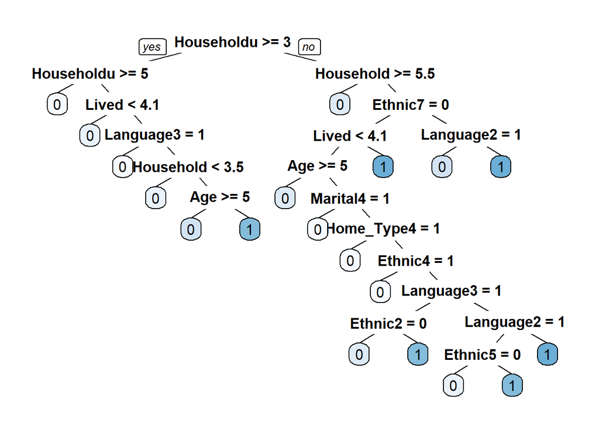

```r
prp(cluster_tree$finalModel,box.palette = "Blues", tweak = 1.2)
```

As we can see from the following visualization, the left nodes of the tree contain the target class 0 while the right nodes contain the target class1 which shows that the tree has clustered the data as per the target class.

```r
predicted <- predict(cluster_tree,accombined_data[,-c(15)])
head(predicted)
```

```
## [1] 0 0 1 0 0 0
## Levels: 0 1
```

```r
confusionMatrix(predicted,accombined_data[,c(15)])
```

```
## Confusion Matrix and Statistics
##
##           Reference
## Prediction    0    1
##          0 8367  637
##          1  626 8356
##
##                Accuracy : 0.9298
##                  95% CI : (0.9259, 0.9335)
##     No Information Rate : 0.5
##     P-Value [Acc > NIR] : <2e-16
##
##                   Kappa : 0.8596
##
##  Mcnemar's Test P-Value : 0.7784
##
##             Sensitivity : 0.9304
##             Specificity : 0.9292
##          Pos Pred Value : 0.9293
##          Neg Pred Value : 0.9303
##              Prevalence : 0.5000
##          Detection Rate : 0.4652
##    Detection Prevalence : 0.5006
##       Balanced Accuracy : 0.9298
##
##        'Positive' Class : 0
##
```